# AS05_Spatial-data-analysis-and-visualization

B10610017 劉宇凡

2024/04/01

## 作業目的

這份作業是希望讓你熟悉`library(sf)`套件的內容，學習使用R語言處理**空間**資料，處理空間資料需要了解一些空間用詞，常見的是`buffer`、`intersect`、`union`、`clip`。向量空間資料一般包含點、線、面三種型式。這個作業會練習到點和面的視覺化方法。

## 1. data-join與交叉分析

這份作業主要使用的資料為`rental`，這是2024年2月全台的租屋市場資料，來源是**開放台灣民間租屋資料**https://rentalhouse.g0v.ddio.io/，但他給的資料中許多欄位是使用編碼，然後再額外給對照的資料，接下來會用到**縣市**與**建築類型**，所以請你先把`rental`與`coding_county`、`coding_county`進行join，並存到`rental_data`中。

接著我想知道**縣市**與**建築類型**的房屋釋出數量，因此請使用join後的資料做交叉分析。請印出交叉分析的結果。(提示：`table()`)

```r
library(readr)
library(sf)
library(ggplot2)
library(dplyr)
library(extrafont)
library(tidyverse)

## 這裡不用動
rental <- read_csv("data/202402_rental.csv")
coding_county <- read_csv("data/編碼表_縣市.csv")
coding_building <- read_csv("data/編碼表_建物類型.csv")

rental <- rental %>% select(最小物件編號, 每坪租金, 建築類型, x, y, 縣市)
missing_values <- is.na(rental$x) | is.na(rental$y)
rental <- rental[!missing_values, ]

## 請你讀取這三個檔案後，觀察一下要怎麼把資料合併起來，才能讓租屋市場資料中，顯示縣市名稱和建築類型名稱。

## your code
rental_data <- rental %>%
    left_join(coding_county, by = "縣市") %>%
    left_join(coding_building, by = "建築類型") %>%
    rename(building_type = 建築類型名稱, county = 縣市名稱) %>%
    filter(building_type %in% c("公寓", "透天", "電梯大樓"))

table(rental_data$county, rental_data$building_type)
```

```
##
##           公寓  透天 電梯大樓
##   宜蘭縣   150   464      439
##   花蓮縣    68   388      245
##   金門縣    11    26        7
##   南投縣    39   283       79
##   屏東縣    63   509      254
##   苗栗縣   139   545      619
##   桃園市  2368  3265     9639
##   高雄市  1323  3202     5759
##   基隆市   713   166      449
##   雲林縣    46   383      159
##   新北市 11077  1548    11217
##   新竹市   303   846     2439
##   新竹縣   135   714     2414
##   嘉義市    51   329      258
##   嘉義縣    15   186       74
##   彰化縣    74   856      266
##   臺中市  3092 12177    23717
##   臺北市 10157  1305    12975
##   臺東縣    18   126       30
##   臺南市   619  3672     3894
##   澎湖縣     3    14        1
```

```r
## result
##           公寓  透天 電梯大樓
##   宜蘭縣   150   464      439
##   花蓮縣    68   388      245
##   金門縣    11    26        7
##   南投縣    39   283       79
##   屏東縣    63   509      254
##   苗栗縣   139   545      619
##   桃園市  2369  3265     9641
##   高雄市  1323  3202     5759
##   基隆市   713   166      449
##   雲林縣    46   383      159
##   新北市 11079  1548    11217
##   新竹市   303   846     2439
##   新竹縣   135   714     2414
##   嘉義市    51   329      258
##   嘉義縣    15   186       74
##   彰化縣    74   856      266
##   臺中市  3092 12179    23718
##   臺北市 10163  1305    12983
##   臺東縣    18   126       30
##   臺南市   619  3672     3894
##   澎湖縣     3    14        1
```

## 2. bar-plot

請把上一題交叉分析的結果畫成bar-plot，三種建築類型要用不同的顏色進行疊加。

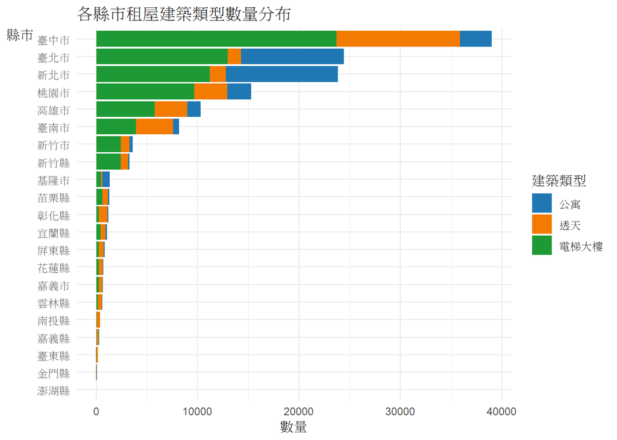

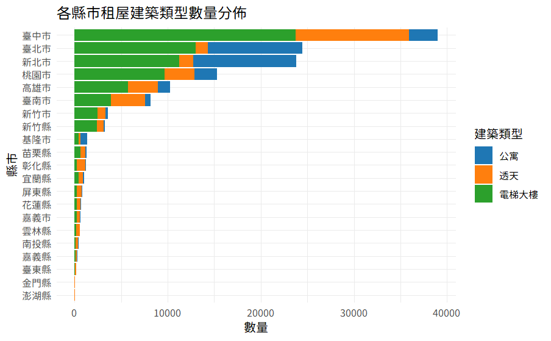

```r
## your code
building_type_plot <- rental %>%
    left_join(coding_county, by = "縣市") %>%
    left_join(coding_building, by = "建築類型") %>%
    rename(building_type = 建築類型名稱, county = 縣市名稱) %>%
    filter(building_type %in% c("公寓", "透天", "電梯大樓")) %>%
    select(county, building_type) %>%
    group_by(county) %>%
    arrange(desc(building_type)) %>%
    count(building_type) %>%
    rename(number = n) %>%
    ungroup()

# 各類型建築顏色
colors <- c("公寓" = "#1f78b4", "透天" = "#f37b02", "電梯大樓" = "#1d9a35")

# 繪製橫向長條圖
building_type_plot %>%
    ggplot(aes(x = reorder(county, number), y = number, fill = factor(building_type, levels = c("公寓", "透天", "電梯大樓")))) +
    geom_bar(stat = "identity") +
    scale_fill_manual(values = colors, guide = guide_legend(title = "建築類型")) +
    labs(title = "各縣市租屋建築類型數量分布",
         x = "縣市",
         y = "數量") +
    scale_y_continuous(breaks = seq(0, 40000, by = 10000)) +
    theme_minimal() +
    theme(axis.title.y = element_text(angle = 0, hjust = 1)) +
    coord_flip()
```

## 3. 轉換為sf格式及座標轉換

### 3-1 將資料轉為sf格式

通常在處理向量空間資料時，有會有兩種情況，一個是拿到`shapefile`檔，另一種是拿到`csv`檔，裡面有經緯度的欄位，需要轉成`sf`格式，才能在空間上呈現。

`rental_data`這份資料的欄位`x`表示經度，`y`表示緯度，並且在**開放台灣民間租屋資料**他們的資料介紹中有說明，這是WGS84的資料。

因為之後要分析臺北市的資料，所以第一步請你先把`rental_data`縣市名稱為**臺北市**的找出來，並重新存成`rental_taipei`。

第二步請你先把`rental_taipei`轉成`sf`格式(提示：`st_as_sf`)，`crs`是4326，另外存為`rental_taipe_sf`

```r
## your code
# 篩選出臺北市的租屋資訊
rental_taipei <- rental_data %>%
    filter(county == "臺北市")

# 轉換成sf格式
rental_taipei_sf <- rental_taipei %>%
    st_as_sf(coords = c("x", "y"), crs = 4326)
```

### 3-2 座標轉換

接著我們要注意的是做空間資料分析時，需要讓座標系統維持一致。現在`rental_taipe_sf`這筆資料的座標是WGS84。

但我們需要一張臺北市行政區的底圖，所以載入`town_map_taipei`並擷取臺北市的資料。`Taipei_town.shp`，這張底圖有他原本的座標系統。

為了統一座標，我們將圖層都轉為`crs = 3826`，也就是TWD97的座標，這種投影方式，會讓經緯度的顯示是以**公尺**為單位。請將結果存到`town_map_taipei_TWD97`。

接著請將上一題的結果`rental_taipei_sf`也轉成TWD97的座標，使用`st_transform`，`crs = 3826`。存到`rental_taipei_sf_TWD97`。

```r
town_map_taipei <- st_read("data/Taipei_town.shp")
## your code
town_map_taipei_TWD97 <- town_map_taipei %>%
    st_transform(crs = 3826)

rental_taipei_sf_TWD97 <- rental_taipei_sf %>%
    st_transform(crs = 3826)
```

## 4. 點分布圖與interection：建築類型

這題的目標是依據*建築類型*分顏色，畫出台北市的租屋市場空間分布情況。除了租屋的點位以外，需要有行政區邊界的底圖，請使用`town_map_taipei_TWD97`。

但是如果直接疊加`rental_taipe_sf_TWD97`與`town_map_taipei_TWD97`，會發現有些點不在臺北市的範圍裏面，這是因為原始的租屋資料本身有幾個座標偏移的資料，所以我們必須把這些點拿掉。

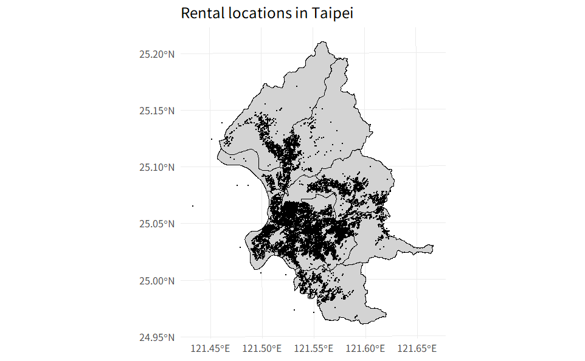

拿掉的方法有很多，可以使用`cilp`，或是`intersect`。但是因為租屋市場這筆資料剛好沒有鄉鎮市區的名稱，所以使用`cilp`時租屋市場的資料，就無法知道臺北市各行政區的名稱了。

這邊希望你拿掉的方法是使用`st_intersection()`這個動詞，用於取兩個圖層的交集。請把取交集後的資料存到`rental_taipei_sf_inter`中，就可以開始繪圖了。畫出來後，請告訴我這張圖有甚麼缺點。

補充：這樣的資料通常還可以用`kernel density`的方法呈現，有興趣可以查查看或右轉地理系溫在弘老師的空間分析。

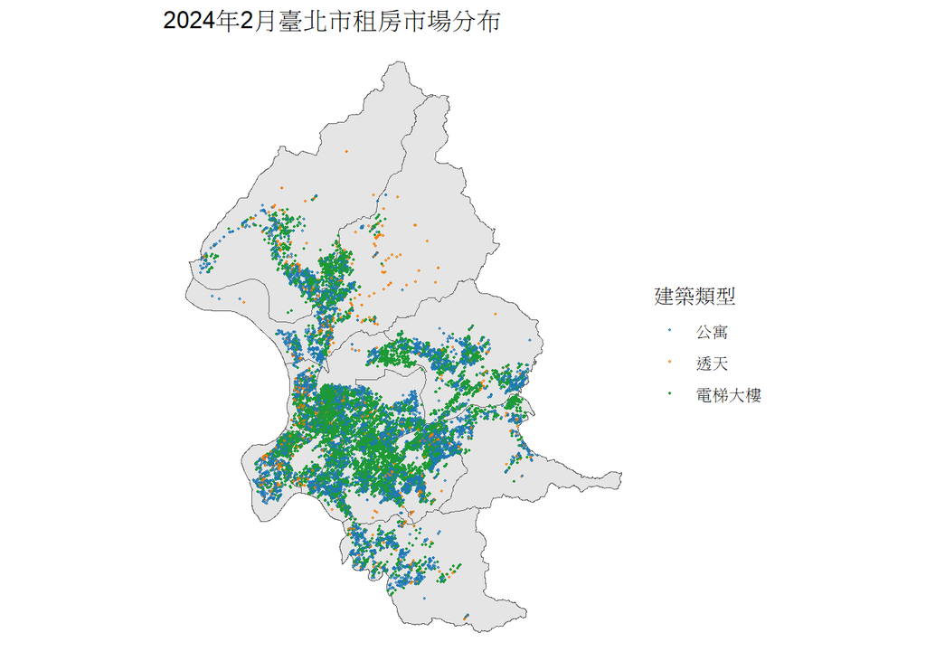

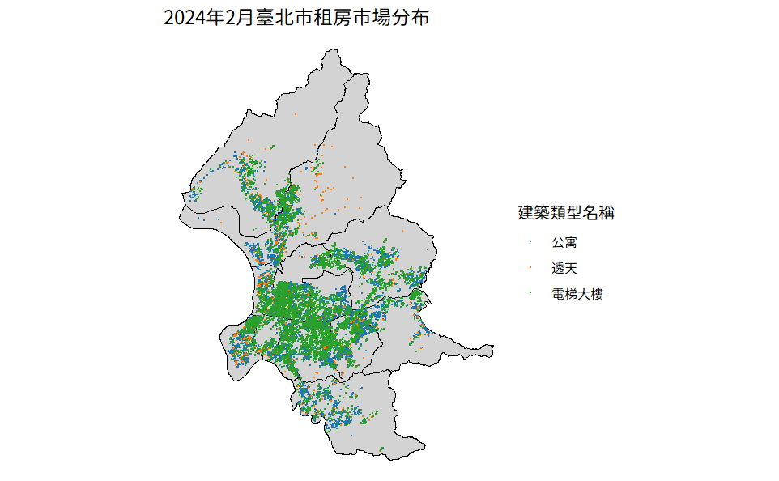

```r
## your code
# 用sf_intersection排除座標偏移的資料
rental_taipei_sf_inter <- st_intersection(town_map_taipei_TWD97, rental_taipei_sf_TWD97)

# 三種建築類型顏色
colors <- c("公寓" = "#1f78b4AA", "透天" = "#f37b02AA", "電梯大樓" = "#1d9a35")

# 繪製臺北市三種建築租屋類型的點位圖
ggplot() +
    geom_sf(data = town_map_taipei_TWD97) +
    geom_sf(data = rental_taipei_sf_inter, aes(color = building_type), size = 0.4) +
    scale_color_manual(values = colors) +
    labs(title = "2024年2月臺北市租房市場分布",
         color = "建築類型") +
    theme_void()
```

## 5. 面量圖：每區的平均租金

這題我想要知道臺北市每個**行政區**的**釋出房屋總數量**與**平均每坪租金**情況，`平均每坪租金`請你使用`rental_taipei_sf_inter`欄位中的`每坪租金`，計算各行政區`平均每坪租金`，並使用顏色呈現租金的高低。

題示：**釋出房屋總數量**的泡泡圖需要用到一點空間概念，圓圈在地圖上呈現，表示他有一個座標，我們通常會使用地理中心點來做為代表，你可能會需要用到`st_centroid()`、`scentroid_coords()`

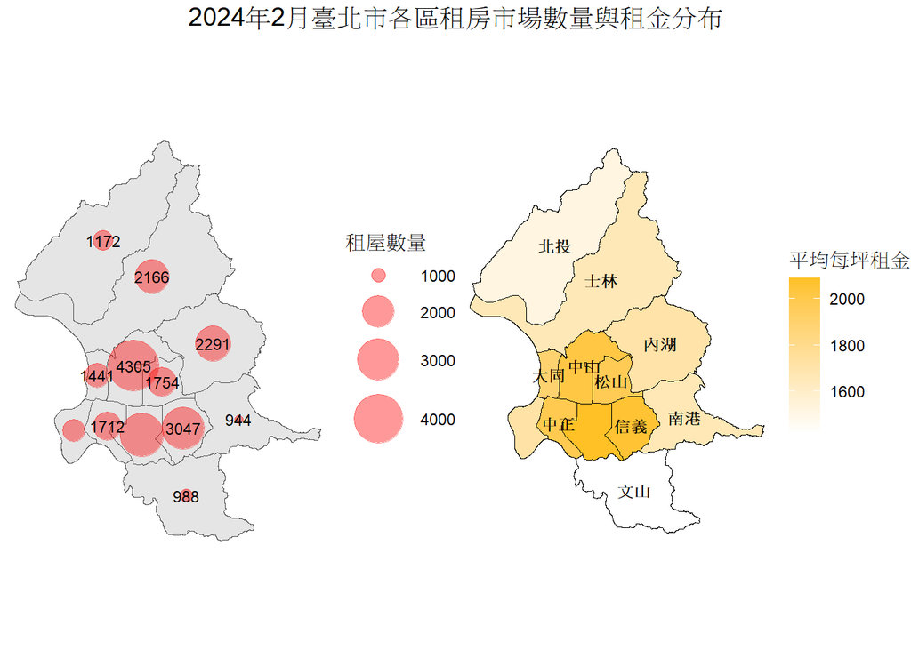

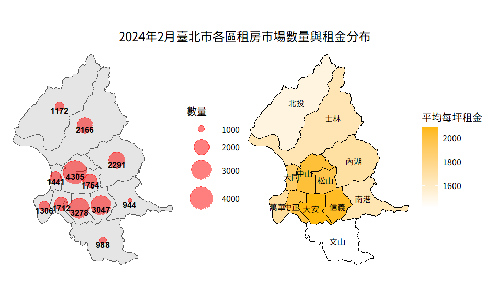

```r
## your code

# 臺北市行政區租屋數量
town_centroid <- town_map_taipei_TWD97 %>%
    st_centroid(geometry) %>%
    select(TOWNNAME, geometry) %>%
    arrange(TOWNNAME)

rental_number <- rental_taipei_sf_inter %>%
    group_by(TOWNNAME) %>%
    count(TOWNNAME) %>%
    rename(租屋數量 = n) %>%
    arrange(TOWNNAME) %>%
    select(TOWNNAME, 租屋數量)

rental_number_centroid <- town_centroid %>%
    cbind(rental_number) %>%
    select(TOWNNAME, 租屋數量, geometry)

# 繪製泡泡圖
plot1 <- ggplot() +
    geom_sf(data = town_map_taipei_TWD97) +
    geom_sf(data = rental_number_centroid, aes(size = 租屋數量, color = "租屋數量"),
            color = "red", alpha = 0.4) +
    scale_size_continuous(range = c(2, 13), breaks = c(1000, 2000, 3000, 4000),
                          labels = c("1000", "2000", "3000", "4000")) +
    geom_text(data = rental_number_centroid, aes(label = 租屋數量,
                                                 x = st_coordinates(geometry)[, "X"],
                                                 y = st_coordinates(geometry)[, "Y"]),
              size = 3, color = "black", nudge_y = 0.005, check_overlap = TRUE) +
    labs(size = "租屋數量") +
    theme_void()


# 臺北市行政區平均每坪租金
town_choropleth <- town_map_taipei_TWD97 %>%
    select(TOWNNAME, geometry) %>%
    arrange(TOWNNAME) %>%
    mutate(geometry2 = st_centroid(geometry))

avg_rental <- rental_taipei_sf_inter %>%
    group_by(TOWNNAME) %>%
    summarize(平均每坪租金 = mean(每坪租金)) %>%
    arrange(TOWNNAME) %>%
    select(TOWNNAME, 平均每坪租金)

avg_rental_choropleth <- town_choropleth %>%
    cbind(avg_rental) %>%
    select(TOWNNAME, 平均每坪租金, geometry)

# 繪製臺北市各行政區平均每坪租金面量圖
colors <- c("white", "khaki1", "goldenrod1")

plot2 <- ggplot() +
    geom_sf(data = town_map_taipei_TWD97) +
    geom_sf(data = avg_rental_choropleth, aes(fill = 平均每坪租金), color = "black") +
    geom_text(data = town_centroid, aes(label = str_sub(TOWNNAME, 1, 2),
                                        x = st_coordinates(geometry)[, "X"],
                                        y = st_coordinates(geometry)[, "Y"]),
              color = "black", fontface = "bold",
              size = 3, check_overlap = TRUE, nudge_y = 0.001) +
    scale_fill_gradient(low = colors[1], high = colors[length(colors)],
                        breaks = c(1600, 1800, 2000), labels = c("1600", "1800", "2000")) +
    labs(fill = "平均每坪租金") +
    theme_void()


# 安裝gridExtra套件
install.packages("gridExtra", repos = "https://cran.r-project.org")
library("gridExtra")
library("grid")

# 合併成一張圖
title <- textGrob("2024年2月臺北市各區租房市場數量與租金分布",
                  gp = gpar(fontsize = 14))
merge_plot <- grid.arrange(plot1, plot2, ncol = 2, top = title)
```

## 6. Buffer：捷運站

租房子的時候，通常會想要找離捷運站近的地方，所以這題我們使用從[國土測繪圖資]所下載的捷運站點位資料進行分析，因為原始資料包含全台的捷運資料，且每個出入口都是一筆資料。我先把他簡化成一個車站一筆資料。請使用簡化後的資料進行繪圖。

這題，我想要看到捷運站Buffer500公尺所涵蓋的範圍，請使用`st_buffer`疊加第四張圖的資訊。請將Buffer後的圖層，存到`buffered_MRT`中。

```r
## 這裡不用動
MRT_map <- st_read("data/MARK_捷運車站_1130216.shp")
```

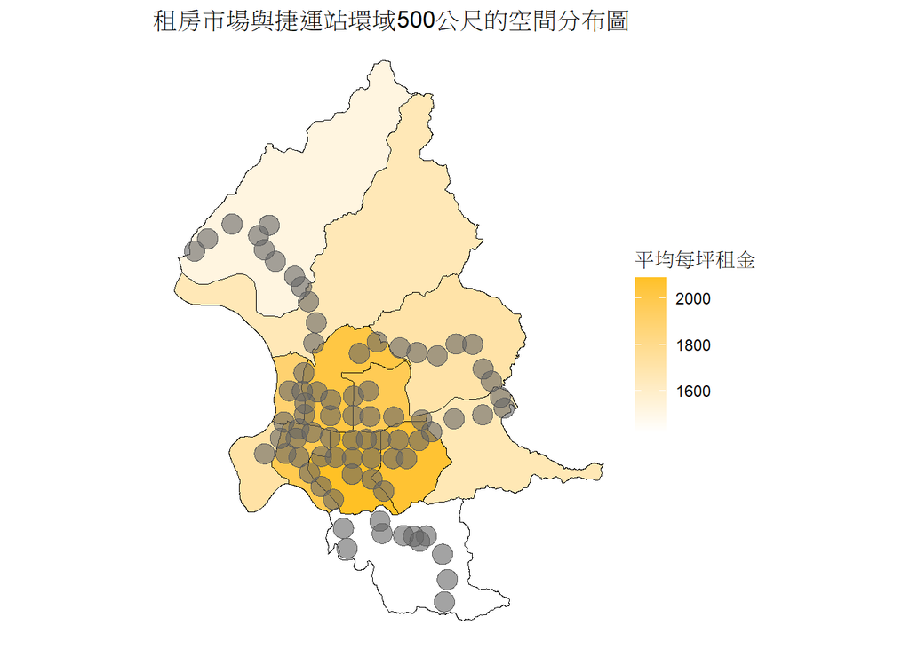

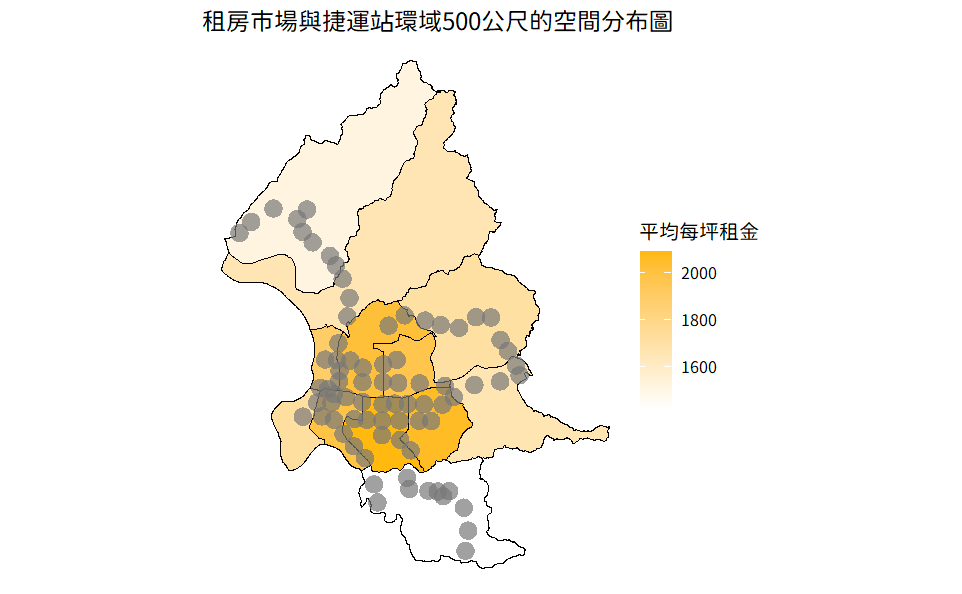

```r
# 轉換TWD97為坐標系
Taipei_MRT_map <- st_transform(MRT_map, crs = 3826)

## your code
# 整理資料
Taipei_MRT_map_cleaned <- Taipei_MRT_map %>%
    filter(str_sub(MARKNAME1, 1, 2) == "臺北" | str_sub(MARKNAME1, 1, 2) == "貓空") %>%
    filter(!grepl("-", MARKNAME1)) %>%
    mutate(mrt_station = str_replace(MARKNAME1, "臺北捷運", "")) %>%
    mutate(mrt_station = gsub("站.*", "", mrt_station)) %>%
    mutate(mrt_station = paste0(mrt_station, "站")) %>%
    arrange(mrt_station) %>%
    select(mrt_station, geometry)


# 取在臺北市行政區地圖內的捷運站再buffer
buffered_MRT <- Taipei_MRT_map_cleaned %>%
    st_intersection(town_map_taipei_TWD97) %>%
    st_buffer(dist = 500) %>%
    select(mrt_station, geometry)

# 疊加圖表
colors <- c("white", "khaki1", "goldenrod1")

ggplot() +
    geom_sf(data = town_map_taipei_TWD97) +
    geom_sf(data = avg_rental_choropleth, aes(fill = 平均每坪租金), color = "black") +
    scale_fill_gradient(low = colors[1], high = colors[length(colors)],
                        breaks = c(1600, 1800, 2000), labels = c("1600", "1800", "2000")) +
    geom_sf(data = buffered_MRT, fill = "gray40", alpha = 0.6) +
    labs(title = "租房市場與捷運站環域500公尺的空間分布圖",
         fill = "平均每坪租金") +
    theme_void()
```

## 7. spatial-join：租金價格與捷運站距離

現在你有了捷運站buffer500公尺`buffered_MRT`的圖層和租屋點位資料`rental_taipei_sf_inter`。我想要知道每個行政區，**在buffer500公尺內的房屋**和**不在buffer500公尺內的房屋**平均每坪租金的情況。請畫成bar圖。

提示：使用`st_join`連接`rental_taipei_sf_inter`和`buffered_MRT`。沒有連接到的就是不在buffer500公尺內的房屋。

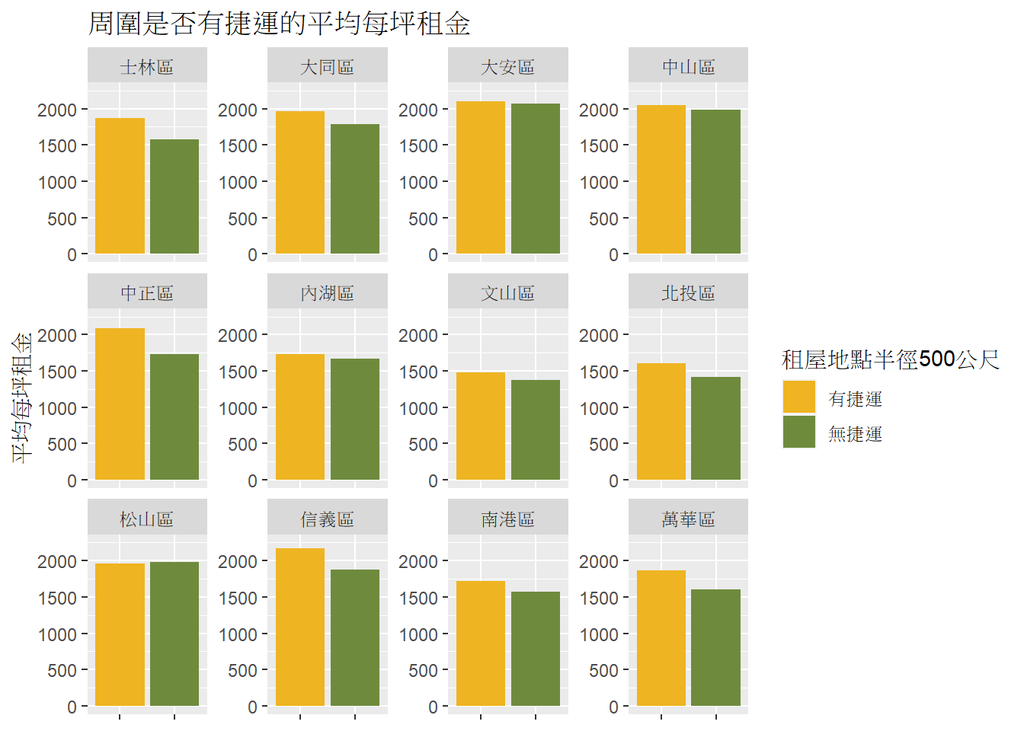

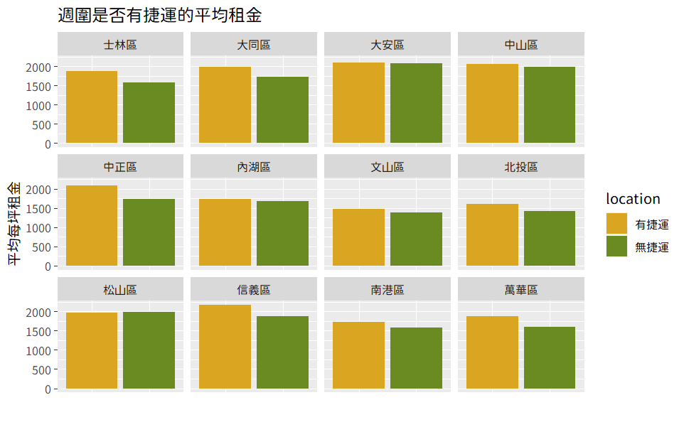

```r
## your code
# 先使用st_join確認租屋地點是否落在捷運站環域500公尺
rental_mrt_inter <- rental_taipei_sf_inter %>%
    st_join(buffered_MRT, join = st_intersects) %>% # 500公尺外的租屋地點在mrt_station這欄為NA
    mutate(mrt_location = if_else(is.na(mrt_station), "無捷運", "有捷運")) %>%
    select(TOWNNAME, mrt_location, 每坪租金) %>%
    group_by(TOWNNAME, mrt_location) %>%
    summarize(平均每坪租金 = mean(每坪租金))

#使用fecet_wrap將各行政區的有無捷運長條圖合併成一張
ggplot(rental_mrt_inter, aes(x = mrt_location, y = 平均每坪租金, fill = mrt_location)) +
    geom_bar(stat = "identity", position = "dodge") +
    scale_fill_manual(values = c("有捷運" = "goldenrod2", "無捷運" = "darkolivegreen4")) +
    scale_y_continuous(breaks = c(0, 500, 1000, 1500, 2000), limits = c(0, 2250)) +
    scale_x_discrete(labels = NULL) +
    facet_wrap(~TOWNNAME, ncol = 4, scales = "free_y") +
    theme(axis.title.x = element_blank(),
          strip.text = element_text(hjust = 0.5)) +
    labs(title = "周圍是否有捷運的平均每坪租金",
         y = "平均每坪租金",
         fill = "租屋地點半徑500公尺")
```

## ChatGPT 預學作業

以下請你用ChatGPT測試看看怎麼用R爬取Youtube的資料。他可能會推薦你用套件，也可能會直接教你設計爬蟲來爬取。但至少必須要取得API key並啟用Youtube data api。請你嘗試用ChatGPT至少撈取到某一個頻道例如（黃國昌的頻道https://www.youtube.com/@KC-Huang 10則影片的標題、ID、描述、發布時間等。並且組織成一個DataFrame，然後印出該Dataframe的內容（會卡關的環節有好幾個，請努力用ChatGPT解決問題）

API金鑰：AIzaSyC9UB4_5uyMwWUQ61-CeavH9yqahuFxFro

```r
## your code
# 載入必要的套件
install.packages("httr", repos = "https://cran.r-project.org")
install.packages("jsonlite", repos = "https://cran.r-project.org")
library(httr)
library(jsonlite)

# 定義函數來從 YouTube API 獲取頻道的最新影片列表
get_channel_videos <- function(channel_id, api_key, max_results = 10) {
    base_url <- "https://www.googleapis.com/youtube/v3/search"
    query <- list(
        part = "snippet",
        channelId = channel_id,
        key = api_key,
        maxResults = max_results,
        order = "date"
        )
    response <- GET(url = base_url, query = query)
    response_content <- content(response, "text", encoding = "UTF-8")
    response_json <- fromJSON(response_content)
    videos <- response_json$items
    return(videos)
}

# 設置 YouTube Data API 金鑰
api_key <- "AIzaSyC9UB4_5uyMwWUQ61-CeavH9yqahuFxFro"

# 指定要抓取的頻道 ID
channel_id <- "KC-Huang"

# 獲取頻道的最新影片列表
videos <- get_channel_videos(channel_id, api_key)

# 整理影片資訊成 dataframe
videos_df <- data.frame(
    title = sapply(videos, function(x) x$snippet$title),
    video_id = sapply(videos, function(x) x$id$videoId),
    description = sapply(videos, function(x) x$snippet$description),
    published_at = sapply(videos, function(x) x$snippet$publishedAt)
)

# 印出 dataframe
print(videos_df)
```

```
## 資料框沒有行但有 0 列
```